# B19b · Forecasting: what is known when?

Research bridge · Elective ◆ · One win: turn a regressor into a forecast without giving it tomorrow's observations

[B19a](https://avistian.github.io/relational/lessons/b19a-predictive-distributions.html) showed why a good mean is not necessarily a good predictive distribution. Now move the prediction into time. A beautiful distribution is useless if its inputs arrive after the decision. For the relational-learning mission, a customer’s future transactions or tomorrow’s observed weather must not enter today’s forecast through a join.

[Student notebook](https://avistian.github.io/relational/labs/b19b-forecasting-contracts.ipynb) · [Executed solution](https://avistian.github.io/relational/labs/html/b19b-forecasting-contracts.html) · [Download solution](https://avistian.github.io/relational/labs/solutions/b19b-forecasting-contracts.ipynb) · [Printable reference](https://avistian.github.io/relational/reference/b19b-forecasting-contracts.html) · [Reproduction contract](https://avistian.github.io/relational/labs/b19b-reproduction.md) · [L201 task worksheet](https://avistian.github.io/relational/labs/b19b-task-contract.md)

## 1 · First reconstruct the decision

A **forecast origin** is the boundary between observed history and the horizon we must predict. This lesson uses zero-based time: origin 96 means history0,…,95 and the first forecast at96. The issue time is95. A **horizon** of12 means predicting96,…,107 together. A **covariate** is any input other than the target: a calendar date, planned promotion or weather measurement. Its event time says when it describes the world; its availability time says when the decision maker could access it.

**Worked prerequisite:** at issue time 10, predict sales at 12. The weekday of12 was already known. An advertisement for12 announced at 8 is also legal. Observed temperature at 12 arrives at 12 and is unavailable. Even a measurement from8 that is delivered at 11 is unavailable at 10. Event time alone cannot enforce this boundary. A weather *forecast issued by 10* could be legal, but it is a different input from the realized weather at 12. Historical data must preserve the appropriate vintage.

Before continuing, retrieve: can future calendar values be legal? Can an old record still arrive too late? Does low WQL establish that either input was legal?

**Availability trace:** issue10 permits calendar and promotion only. At11 the delayed measurement arrives; at12 observed weather arrives. Future targets stay hidden.

The control changes arrival information, not the event being forecast. Legal access follows **available_at ≤ issue_time**. Target observations for the forecast horizon are always withheld from model construction. A database’s current rows are not necessarily its historical state; use an as-of snapshot or an arrival/revision log.

## 2 · Model architecture: TabPFN-TS is a wrapper around a regressor

Read [From Tables to Time, §§3–4 and Appendix A.3](https://arxiv.org/html/2501.02945v4). TabPFN-TS represents each time step as a row, constructs temporal features, and asks a pretrained TabPFN-v2 regressor to predict future rows. It does not require time-series-specific pretraining. This is a particular forecasting construction, not a capability automatically inherited by every tabular model.

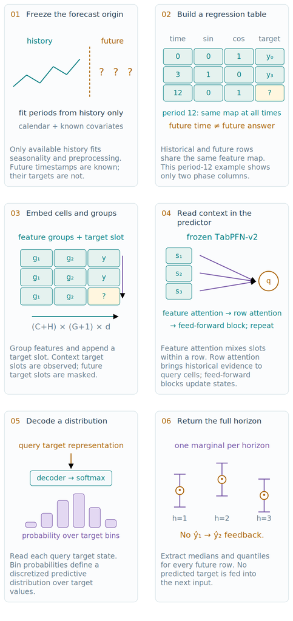

From historical observations to future feature rows and predictive distributions. On narrow screens, scroll horizontally.

Let **C** be the number of retained context observations, **H** the forecast horizon and **D** the input-feature count. History is `X_context[C,D]` with observed `y_context[C]`; future inputs are `X_query[H,D]` with hidden labels. The full paper feature recipe has a running index,17 calendar columns,10 automatic-seasonality columns and any legal covariates: D=28 plus the covariate count. Missing seasonal slots are zero-filled. These are numerical features, not words tokenized by an LLM.

The running index marks progression. Calendar features encode known cycles with sine/cosine pairs. Automatic seasonal features estimate periods **from history**, then evaluate their sine/cosine coordinates at both historical and future positions. For period 12, the pair is `(sin(2πt/12), cos(2πt/12))`. At t=0 and12 it is(0,1); at t=3 it is(1,0). The pair distinguishes phases that sine alone merges. Knowing the future phase does not reveal its target.

Inside the pretrained regressor, grouped feature values and the target slot become vectors of width d. The schematic tensor is `(C+H) × (G+1) × d`, where G is the checkpoint’s feature-group count. Repeated feature-attention blocks exchange information within a row; row attention transfers information from observed support rows to query representations; feed-forward layers transform those representations. The query target representation feeds probabilities over target bins. This is the v2 mechanism recalled from [B03](https://avistian.github.io/relational/lessons/b03-pfn-tabpfn-generations.html); exact group size, depth and ensemble settings belong to the authenticated checkpoint/configuration, not to our diagram.

**Forward-pass trace:** history determines the temporal feature fit and the support labels; the same frozen feature map builds H future rows; the regressor returns H predictive distributions. Read a median for absolute error and quantiles for uncertainty scores. No earlier predicted target is fed back as the next input in this non-autoregressive construction. It produces marginal forecasts at each horizon position; do not assume a coherent joint distribution over whole future paths.

**Visible implementation boundary:** the notebook implements forecast contracts and the archived wrapper's seasonal extraction. It provides the full original wrapper source packet and an optional complete97-task operator. Its small ridge experiment below is explicitly a course mechanism. It does not implement or run pretrained TabPFN attention.

## 3 · Learning the period is also fitting

A seasonal pattern means that a component repeats with a period. **Detrending** removes a fitted linear component before searching for repeated oscillations. A **Fourier transform** expresses the resulting signal as frequencies; a spectral peak suggests a repeating component. A **Hann window** reduces abrupt edge effects before that transform. Zero-padding samples the spectrum more finely; it does not add new observations or establish a true period.

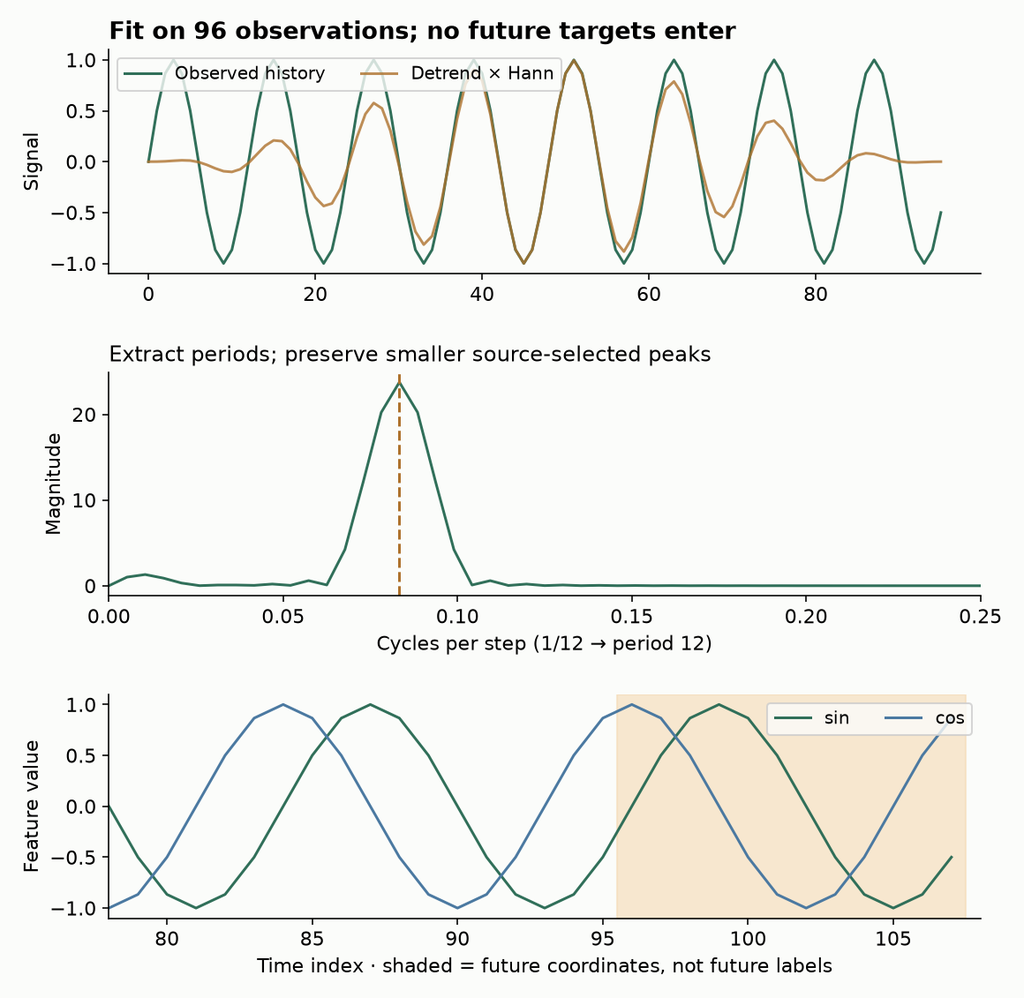

Historical signal → spectral periods → future coordinates. On narrow screens, scroll horizontally.

The visible source mirror follows the archived default pipeline: fit a line on history, subtract it, multiply by a Hann window, append zeros to double its length, compute Fourier magnitudes, remove the zero-frequency component, retain peaks above 5% of the maximum, take up to 5, round inverse frequencies to periods, deduplicate and sort by magnitude. Then construct future sine/cosine columns from those periods. [Archived implementation](https://avistian.github.io/relational/labs/sources/b19b/wrapper/tabpfn_time_series/features/auto_features.py)

**Audit result:** four source-parity cases pass, including period 12 and mixed periods 12/8. A constant input can still yield peaks from tiny numerical residuals. Agreement with released code is not proof that every detected seasonality is meaningful. The paper pseudocode describes a convolution/symmetric padding, whereas this source uses multiplication/right padding. We expose the difference rather than quietly change the implementation.

**CHECK:** why is concatenating future timestamps acceptable, but using future targets to choose spectral peaks invalid? The archived transformer explicitly requires missing query targets. If a future-label intervention changes learned periods, the boundary is broken. Dropping missing observations also changes the index geometry; preserve and audit its interaction with calendar timestamps.

## 4 · Evaluate the forecast you could have issued

In **rolling-origin evaluation**, the issue time advances. Refit any data-dependent preprocessing on that origin’s history; predict the entire declared horizon without seeing its targets; then score. At the next origin, targets that have now arrived may become history. This is an expanding context here, not a random row split.

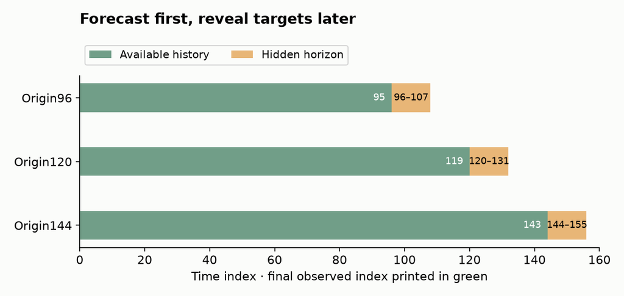

Three expanding histories and complete twelve-step horizons. On narrow screens, scroll horizontally.

Our fixed origins96,120,144 each predict12 steps. Their forecast windows do not overlap, but their training histories do. They are not independent datasets. In a larger study, keep validation origins for model/feature selection separate from the final evaluation origins. If labels arrive late, the historical prefix itself also needs an availability filter; the course generator assumes immediate target arrival.

A **seasonal-naive** point forecast copies the last observed value at the same seasonal phase. With period 12, the point forecast at96 copies84. This is a useful first baseline. A stronger baseline should have the same legal covariates and selection budget as the challenger: for example, a tuned feature-based tree or an appropriate statistical model. The course’s fixed ridge predictor is illustrative, not an exhaustive baseline comparison.

**MASE** divides mean absolute median-forecast error by the mean historical error of a seasonal-naive predictor. For history y₀,…,yC−1 and seasonal lag s:

`scale = mean(|y_t − y_(t−s)|, t=s,…,C−1)`

`MASE = mean(|future_y − forecast_median|) / scale`.

For history[1,3,2,4] and s=1, scale=(2+1+2)/3=5/3. Future observations[2,4] and medians[1,5] have mean absolute error1, so MASE=0.6. MASE<1 means lower error than the **historical scaling error**; it does not guarantee beating seasonal naive on the held-out horizon. A constant history gives scale0; our teaching scorer refuses the undefined ratio. A benchmark must declare its own zero policy.

**Weighted quantile loss (WQL)** evaluates forecast quantiles. A q-quantile puts q of the probability at or below it. With error e=y−prediction, pinball loss is `max(qe,(q−1)e)`. WQL doubles the sum of pinball losses, divides by the sum of absolute target values, then averages over q=0.1,…,0.9. Underprediction costs more at a high quantile. At q=.5, doubled pinball loss is absolute error. For the two median predictions above, WQL=2/6=1/3.

WQL is a quantile-grid approximation related to B19a’s CRPS; it is not full-CDF evaluation or proof of calibration. Its denominator weights large-magnitude series when pooled. Our lab averages origin scores within seeds; a benchmark evaluator may pool differently. Zero total absolute target magnitude is explicitly rejected here. [GIFT evaluation code](https://avistian.github.io/relational/labs/sources/b19b/wrapper/gift_eval/evaluate.py)

## 5 · A better score from forbidden information

**Frozen course experiment:**3 seeds × 3 origins × 3 arms;156 generated steps per seed;12-step horizons. Demand is20 plus a period 12 sine, a scheduled promotion,4×weather and noise. Promotion is announced24steps ahead; weather is independent and observed only at its event time. The three arms use seasonal naive, fixed ridge with legal seasonal/promotion features, and the same ridge with future observed weather. All origins, coefficients, seeds and regularization were fixed without outcome-based selection.

The ridge arms minimize squared training error plus a fixed coefficient penalty. We add empirical training-residual quantiles to their point predictions. The seasonal arm adds median-centered historical seasonal-difference quantiles to its seasonal point forecast. These are simple distribution heuristics; neither has a formal coverage guarantee. This manufactured problem isolates information access and provides no general TabPFN performance evidence.

| Arm | Mean MASE ↓ | Mean WQL ↓ | WQL by seed0 /1 /2 |
| --- | --- | --- | --- |
| seasonal_naive | 0.9159 | 0.1556 | 0.1794 / 0.1594 / 0.1281 |
| legal_regression | 0.7385 | 0.1251 | 0.1309 / 0.1111 / 0.1333 |
| oracle_weather | 0.0797 | 0.0136 | 0.0137 / 0.0114 / 0.0157 |

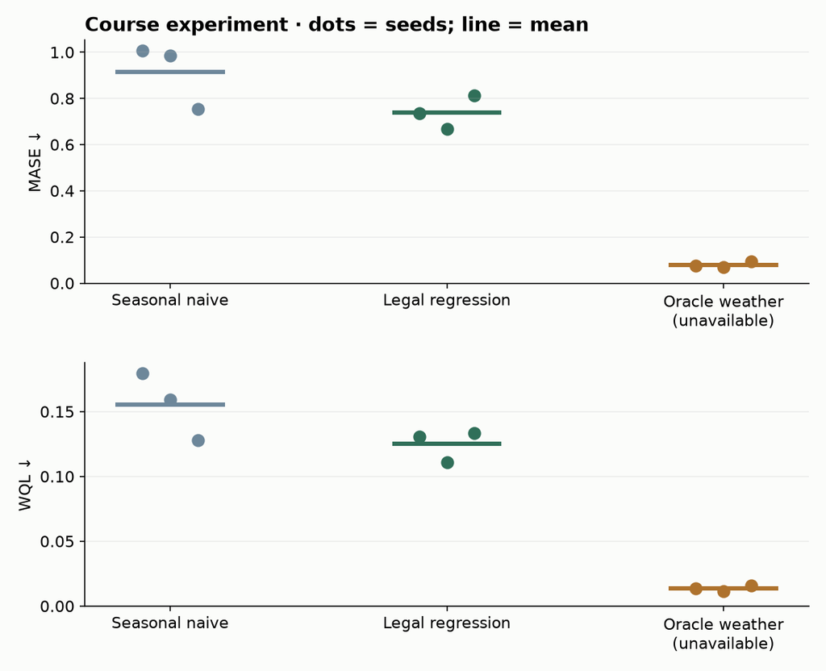

All three seeds retained; oracle weather is unavailable at forecast issue time. On narrow screens, scroll horizontally.

The illegal oracle’s improvement answers a different question: how well could we predict if we already knew future weather? It cannot justify deployment. Legal regression also does not beat seasonal naive on every seed; keep that negative result. Across 9 paired origin/seed interventions, changing unavailable weather leaves legal inputs and forecasts fixed, while the oracle changes. All 324 prediction keys and 27 metric calculations are independently checked.

**Falsification test:** replace all unavailable future covariates and labels, preserving the historical inputs. Legal feature fits and forecasts must remain fixed. This test can expose an information path; passing it does not prove that every possible leak has been removed.

## 6 · Full reproduction attempt: the score file is part of the experiment

The approved target is the complete **v4 Figure 4.1**, not one convenient dataset. We recovered all 97 task records for each of its 13 plotted models: **1,261 released records**. The model roster comes from the actual figure, which includes Sundial/PatchTST and omits AutoETS despite the surrounding prose. The notebook recomputes equal-task geometric score ratios and tied WQL ranks from the complete matrix.

| Model | WQL rank: released / paper | Relative WQL: released / paper | Relative MASE: released / paper |
| --- | --- | --- | --- |
| TiRex | 2.526 / 2.515 | 0.488 / 0.413 | 0.716 / 0.642 |
| Toto-1.0 | 4.247 / 4.237 | 0.517 / 0.437 | 0.750 / 0.673 |
| Moirai-2 | 4.485 / 4.464 | 0.516 / 0.436 | 0.728 / 0.654 |
| TabPFN-TS | 5.402 / 5.392 | 0.544 / 0.460 | 0.771 / 0.692 |
| TimesFM-2.0 | 5.474 / 5.454 | 0.550 / 0.465 | 0.758 / 0.680 |
| Chronos-Bolt-Base | 5.887 / 5.866 | 0.574 / 0.485 | 0.808 / 0.725 |
| Sundial-Base | 6.412 / 6.402 | 0.559 / 0.472 | 0.750 / 0.673 |
| PatchTST | 6.985 / 6.943 | 0.587 / 0.496 | 0.849 / 0.762 |
| TFT | 7.253 / 7.222 | 0.605 / 0.511 | 0.915 / 0.822 |
| DeepAR | 9.706 / 9.624 | 0.853 / 0.721 | 1.343 / 1.206 |
| Auto-Arima | 10.474 / 10.284 | 0.912 / 0.770 | 1.074 / 0.964 |
| Auto-Theta | 10.985 / 10.923 | 1.244 / 1.051 | 1.090 / 0.978 |
| Seasonal-Naive | 11.165 / 11.675 | 1.000 / 1.000 | 1.000 / 1.000 |

Only **2 of 39** displayed values match to 3 decimals: SeasonalNaive’s two relative scores equal1 by construction. The released matrix is completely reconstructed, but the historical figure remains **INCOMPLETE_SOURCE_PROTOCOL_GATE**. The confidence intervals are not reconstructed: their original resampling procedure and unit have not been authenticated. We do not create substitute error bars and call them the paper’s.

The dated repository contains a January2025 TabPFN score file, whereas GIFT updated its file in May2025; we use the same pinned GIFT snapshot for all 13 models. GIFT also documents a July2025 baseline correction. Its pre-correction repository file contains only4tasks and cannot fill the97-task contract. The historical candidates’ dependencies, backend choices and checkpoint names differ. These are concrete source/version questions, not permission to select the file that produces the desired rank. [Complete audit](https://avistian.github.io/relational/labs/evidence/b19b/reproduction.json) · [Original figure](https://avistian.github.io/relational/labs/sources/b19b/figure4-1.svg) · [GIFT snapshot](https://github.com/SalesforceAIResearch/gift-eval/tree/2c13c6ff6fd7557c4353674c800d41995f280233)

**Evidence ledger:** course diagnostic and source-seasonality checks complete; released-score reconstruction complete; original figure identity/intervals incomplete; fresh benchmark inference, raw-prediction rescoring and pretraining NOT_RUN. Paid spendUSD 0. The portable notebook replays saved scores, not pretrained model predictions. The optional full evaluation operator is provided but its model execution is untested. [Full contract and commands](https://avistian.github.io/relational/labs/b19b-reproduction.md)

## Run contract

Python3 with NumPy and SciPy; no repository imports, downloads, credentials or model calls. All figures and score/source bytes are embedded. Install numpy/scipy in your own environment if absent; Colab usually provides them. Live Colab frontend NOT_CHECKED. PROVIDED scaffolding is complete; implement three TODO functions, run their CHECKs, then produce the EXIT artifact. Historical source files are evidence; they are not imported by core execution.

```python
# @colab-bootstrap
import math,random,json,unittest,base64,gzip,hashlib
from pathlib import Path
import numpy as np
import scipy
print("NumPy",np.__version__,"SciPy",scipy.__version__)
```

```
NumPy 2.5.0 SciPy 1.18.0
```

```python
class ForecastTests(unittest.TestCase):
 def test_availability(self):
  rows=[dict(id='calendar',time=12,available_at=0,value=2),dict(id='weather',time=12,available_at=12,value=9),dict(id='late',time=8,available_at=11,value=3)]
  self.assertEqual(available_features(rows,10),{'calendar':2})
  changed=[dict(x,value=999) if x['id']!='calendar' else x for x in rows]
  self.assertEqual(available_features(rows,10),available_features(changed,10))
  self.assertEqual(available_features(rows,12),{'calendar':2,'weather':9,'late':3})
  with self.assertRaises(ValueError):available_features(rows+[rows[0]],10)
  with self.assertRaises(ValueError):available_features([dict(id='a',time=1,value=2)],10)
 def test_origins(self):
  self.assertEqual(rolling_origins(12,4,3,3),[(4,[4,5,6]),(7,[7,8,9])])
  self.assertEqual(rolling_origins(7,4,3,1),[(4,[4,5,6])])
  for args in [(12,4,0,1),(12,4,3,0),(12,0,3,1),(12,11,3,1)]:
   with self.assertRaises(ValueError):rolling_origins(*args)
 def test_scores(self):
  s=forecast_scores([1,3,2,4],[2,4],[[1],[5]],[.5],1)
  self.assertAlmostEqual(s['mase'],.6);self.assertAlmostEqual(s['wql'],1/3)
  self.assertAlmostEqual(s['scale'],5/3)
  # Correct asymmetric quantile loss: q=.1, y=2, prediction=0 -> 2*.1*2/2=.2
  self.assertAlmostEqual(forecast_scores([1,2],[2],[[0,1]],[.1,.5],1)['wql'],.35)
  for h,y,p,q,sn in [([1,1],[2],[[1]],[.5],1),([1,2],[0],[[1]],[.5],1),([1,2],[2],[[3,1]],[.1,.5],1),([1,2],[2],[[1]],[.1],1)]:
   with self.assertRaises(ValueError):forecast_scores(h,y,p,q,sn)
```

## SOLUTION · available_features

Select unique cells available at the issue time. Reject ambiguous identities and missing availability metadata. The full experiment calls this function; its result is not bypassed by a saved answer.

```python
def available_features(records, origin):
    """As-of lookup: each unique feature cell has an explicit arrival time."""
    result={};seen=set()
    for row in records:
        if not all(k in row for k in ('id','time','available_at','value')):
            raise ValueError('Feature cell requires identity, event time, availability and value')
        if row['id'] in seen:raise ValueError('Duplicate feature identity')
        seen.add(row['id'])
        if not math.isfinite(row['available_at']):raise ValueError('Invalid availability')
        if row['available_at']<=origin:result[row['id']]=row['value']
    return result
```

### CHECK · hand trace and invalid inputs

```python
ForecastTests('test_availability').debug()
print('available_features: passed')
```

```
available_features: passed
```

## SOLUTION · rolling_origins

Construct all complete chronological query horizons. Reject invalid lengths and a partial first horizon. The full experiment calls this function; its result is not bypassed by a saved answer.

```python
def rolling_origins(length, first, horizon, step):
    """Origin is the first forecast index; history is range(origin)."""
    if any(type(x) is not int or x<=0 for x in (length,first,horizon,step)) or first+horizon>length:
        raise ValueError('Require positive integers and a complete first horizon')
    return [(o,list(range(o,o+horizon))) for o in range(first,length-horizon+1,step)]
```

### CHECK · hand trace and invalid inputs

```python
ForecastTests('test_origins').debug()
print('rolling_origins: passed')
```

```
rolling_origins: passed
```

## SOLUTION · forecast_scores

Compute the historical seasonal denominator and asymmetric pinball losses. Validate shape, finite values and ordered quantiles; fail on zero denominators. The full experiment calls this function; its result is not bypassed by a saved answer.

```python
def forecast_scores(history, actual, quantiles, levels, season):
    """Median MASE and mean quantile loss; fail explicitly on zero denominators."""
    h=np.asarray(history,dtype=float);y=np.asarray(actual,dtype=float)
    p=np.asarray(quantiles,dtype=float);q=np.asarray(levels,dtype=float)
    if h.ndim!=1 or y.ndim!=1 or q.ndim!=1 or p.shape!=(len(y),len(q)) or not len(y):raise ValueError('Bad dimensions')
    if type(season) is not int or season<1 or len(h)<=season:raise ValueError('Insufficient seasonal history')
    if not all(np.isfinite(a).all() for a in (h,y,p,q)):raise ValueError('Nonfinite input')
    if not np.all((q>0)&(q<1)) or not np.all(np.diff(q)>0) or .5 not in q:raise ValueError('Ordered levels must include median')
    if not np.all(np.diff(p,axis=1)>=0):raise ValueError('Crossing quantiles')
    scale=float(np.mean(np.abs(h[season:]-h[:-season])));denom=float(np.abs(y).sum())
    if scale<=0 or denom<=0:raise ValueError('Undefined scale; declare benchmark-specific policy separately')
    error=y[:,None]-p;pinball=np.maximum(q*error,(q-1)*error)
    return dict(mase=float(np.abs(y-p[:,list(q).index(.5)]).mean()/scale),wql=float(2*pinball.sum(axis=0).mean()/denom),scale=scale)
```

### CHECK · hand trace and invalid inputs

```python
ForecastTests('test_scores').debug()
print('forecast_scores: passed')
```

```
forecast_scores: passed
```

## PROVIDED · visible paper-wrapper mechanism

These two functions mirror the archived default spectral extraction and build10seasonal columns. This is source code parity for selected cases, not pretrained model inference. Constant histories can produce numerical residual peaks. Inspect intermediate periods before trusting their meaning.

```python
def source_periods(history, k=5):
    """Mirror archived AutoSeasonalFeature.Config defaults; source/code differences documented."""
    from scipy import fft
    from scipy.signal import find_peaks
    x=np.asarray(history,dtype=float);x=x[~np.isnan(x)]
    if len(x)<3 or not np.isfinite(x).all():raise ValueError('Need at least three finite observations')
    t=np.arange(len(x));x=(x-np.polyval(np.polyfit(t,x,1,rcond=None),t))*np.hanning(len(x))
    magnitude=np.abs(fft.rfft(np.pad(x,(0,len(x)))));magnitude[0]=0
    frequencies=np.fft.rfftfreq(2*len(x))
    peaks,_=find_peaks(magnitude,height=.05*np.max(magnitude))
    if not len(peaks):peaks=np.arange(len(magnitude))
    indices=peaks[np.argsort(magnitude[peaks])[::-1]][:k]
    periods=np.zeros_like(frequencies);nonzero=frequencies>0;periods[nonzero]=1/frequencies[nonzero]
    top=np.round(periods[indices]);valid=top!=0;top=top[valid];indices=indices[valid]
    unique=np.unique(top,return_index=True)[1]
    return sorted([(float(top[i]),float(magnitude[indices[i]])) for i in unique],key=lambda x:x[1],reverse=True)

def source_seasonal_features(history, horizon):
    """History-only period fitting; future targets never enter this interface."""
    found=source_periods(history);periods=[x[0] for x in found];t=np.arange(len(history)+horizon)
    a=np.zeros((len(t),10))
    for i,p in enumerate(periods):a[:,2*i]=np.sin(2*np.pi*t/p);a[:,2*i+1]=np.cos(2*np.pi*t/p)
    return a[:len(history)],a[len(history):],periods
```

```python
history=np.sin(2*np.pi*np.arange(96)/12)
train_features,query_features,periods=source_seasonal_features(history,12)
assert train_features.shape==(96,10) and query_features.shape==(12,10)
assert periods[0]==12
print('Learned source periods:',periods)
```

```
Learned source periods: [12.0, 96.0]
```

## PROVIDED · fixed course models and complete experiment

Read the four-column legal model and five-column oracle. Future observed weather appears only in the declared illegal arm. In-sample residual quantiles have no coverage guarantee. No choice is made from final outcomes.

```python
def temporal_features(times):
    """Visible fixed course features. Not the full paper's feature extractor."""
    t=np.asarray(times,dtype=float)
    return np.column_stack([np.ones(len(t)),np.sin(2*np.pi*t/12),np.cos(2*np.pi*t/12),(t.astype(int)%24<3).astype(float)])
```

```python
def fit_predict(history_times, history_y, query_times, history_weather=None, query_weather=None, query_promotion=None):
    """Fixed ridge + in-sample residual quantiles: teaching model, no calibration guarantee."""
    x=temporal_features(history_times);z=temporal_features(query_times)
    if query_promotion is not None:z[:,3]=query_promotion
    if history_weather is not None:
        x=np.column_stack([x,history_weather]);z=np.column_stack([z,query_weather])
    beta=np.linalg.solve(x.T@x+1e-6*np.eye(x.shape[1]),x.T@history_y)
    residual=history_y-x@beta
    return z@beta[:,None]+np.quantile(residual,np.arange(1,10)/10)[None,:]
```

```python
def run_experiment():
    """Frozen 3 seeds x 3 origins x 3 arms x 12 steps; no selection."""
    levels=[i/10 for i in range(1,10)];series=[];predictions=[];scores=[];interventions=[]
    for seed in [0,1,2]:
        rng=random.Random(seed);weather=np.array([rng.gauss(0,1) for _ in range(156)])
        noise=np.array([rng.gauss(0,.5) for _ in range(156)]);t=np.arange(156)
        y=temporal_features(t)@np.array([20,3,0,2])+4*weather+noise
        series.append(dict(seed=seed,target=y.tolist(),weather=weather.tolist()))
        for origin,query in rolling_origins(156,96,12,24):
            # Issue immediately before origin. Calendar/promotion are announced 24 steps ahead.
            cells=[dict(id=f'{name}/{i}',time=i,available_at=i-24 if name=='promotion' else i,value=float((i%24<3) if name=='promotion' else weather[i])) for i in query for name in ['promotion','weather']]
            allowed=available_features(cells,origin-1)
            assert len(allowed)==12 and all(k.startswith('promotion/') for k in allowed)
            hist=y[:origin];qt=np.array(query)
            promotion=[allowed[f'promotion/{i}'] for i in query]
            legal=fit_predict(np.arange(origin),hist,qt,query_promotion=promotion)
            oracle=fit_predict(np.arange(origin),hist,qt,weather[:origin],weather[qt])
            differences=hist[12:]-hist[:-12]
            offsets=np.quantile(differences,levels);offsets-=offsets[4]
            naive=hist[origin-12:origin,None]+offsets[None,:]
            for arm,p in [('seasonal_naive',naive),('legal_regression',legal),('oracle_weather',oracle)]:
                score=forecast_scores(hist,y[qt],p,levels,12)
                scores.append(dict(seed=seed,origin=origin,arm=arm,**score))
                predictions.extend(dict(seed=seed,origin=origin,time=i,arm=arm,y=float(y[i]),quantiles=p[j].tolist()) for j,i in enumerate(query))
            mutated=[dict(c,value=c['value']+100) if c['id'].startswith('weather/') else c for c in cells]
            assert available_features(mutated,origin-1)==allowed
            # Legal prediction receives only immutable history and timestamps; no future target input.
            changed_allowed=available_features(mutated,origin-1)
            changed=fit_predict(np.arange(origin),hist,qt,query_promotion=[changed_allowed[f'promotion/{i}'] for i in query])
            interventions.append(dict(seed=seed,origin=origin,unavailable_feature_change_invariant=available_features(mutated,origin-1)==allowed,legal_predictions_invariant=bool(np.array_equal(changed,legal)),oracle_prediction_change=float(np.max(np.abs(fit_predict(np.arange(origin),hist,qt,weather[:origin],weather[qt]+100)-oracle)))))
    summary=[]
    for arm in ['seasonal_naive','legal_regression','oracle_weather']:
        by_seed=[]
        for seed in [0,1,2]:
            rows=[x for x in scores if x['arm']==arm and x['seed']==seed]
            by_seed.append(dict(seed=seed,**{m:sum(x[m] for x in rows)/len(rows) for m in ['mase','wql']}))
        summary.append(dict(arm=arm,by_seed=by_seed,**{m:sum(x[m] for x in by_seed)/3 for m in ['mase','wql']}))
    return dict(experiment='B19b-FORECAST-AVAILABILITY',status='COMPLETE_COURSE_DIAGNOSTIC',levels=levels,series=series,predictions=predictions,scores=scores,summary=summary,interventions=interventions,not_tabpfn=True)
```

```python
report=run_experiment()
assert len(report['predictions'])==324 and len(report['scores'])==27
assert all(x['unavailable_feature_change_invariant'] and x['legal_predictions_invariant'] for x in report['interventions'])
Path('b19b-diagnostic.json').write_text(json.dumps(report,indent=2)+'\n')
for row in report['summary']:print(row)
```

```
{'arm': 'seasonal_naive', 'by_seed': [{'seed': 0, 'mase': 1.007127586059456, 'wql': 0.17937577997800722}, {'seed': 1, 'mase': 0.9870142885546974, 'wql': 0.15944986363839111}, {'seed': 2, 'mase': 0.7535599064731917, 'wql': 0.12810789647215506}], 'mase': 0.9159005936957817, 'wql': 0.15564451336285112}
{'arm': 'legal_regression', 'by_seed': [{'seed': 0, 'mase': 0.7349969283487158, 'wql': 0.13085128748901562}, {'seed': 1, 'mase': 0.6673670968111924, 'wql': 0.11113682272064325}, {'seed': 2, 'mase': 0.8130996743411437, 'wql': 0.13328220685032946}], 'mase': 0.738487899833684, 'wql': 0.1250901056866627…
{'arm': 'oracle_weather', 'by_seed': [{'seed': 0, 'mase': 0.07561019986518609, 'wql': 0.013739319209027705}, {'seed': 1, 'mase': 0.0701116197816916, 'wql': 0.011352386157098335}, {'seed': 2, 'mase': 0.09329397803362588, 'wql': 0.01570917121041362}], 'mase': 0.07967193256016786, 'wql': 0.013600292192…
```

## Saved-score replay · all13 models and97 tasks

This packet contains1,261original released task scores. It contains no raw per-series predictions. We recompute all39 aggregate values; the original figure remains source-gated, and no confidence interval method is invented. Hash checks bind the embedded bytes.

```python
packed=base64.b64decode('H4sIAAAAAAACA62929Jlx3Wdea+nUOi6Wczzoe/kZij6Rg63xQhdIopgtYg2…=')
assert hashlib.sha256(packed).hexdigest()=='aa177fb1480d244bcc88a96409c017fbf9b6414b556dfa3f1e8e3c9012e25da3'
records=json.loads(gzip.decompress(packed))
```

```python
def replay(records):
    """Equal task weight, geometric ratios and average tied WQL ranks; no missing imputation."""
    roster=list(records);keys=sorted(records['Seasonal-Naive'])
    if len(roster)!=13 or len(keys)!=97 or any(set(records[m])!=set(keys) for m in roster):raise ValueError('Incomplete model/task support')
    for model in roster:
        for key in keys:
            if any(not math.isfinite(records[model][key][m]) or records[model][key][m]<=0 for m in ['mase','wql']):raise ValueError('Nonpositive/nonfinite score')
    result=[]
    for model in roster:
        ranks=[]
        for key in keys:
            v=records[model][key]['wql'];values=[records[m][key]['wql'] for m in roster]
            ranks.append(1+sum(x<v for x in values)+(sum(x==v for x in values)-1)/2)
        row=dict(model=model,mean_wql_rank=sum(ranks)/len(keys))
        for metric in ['wql','mase']:
            row['relative_'+metric]=math.exp(sum(math.log(records[model][k][metric]/records['Seasonal-Naive'][k][metric]) for k in keys)/len(keys))
        result.append(row)
    return dict(tasks=len(keys),models=len(roster),records=len(keys)*len(roster),rows=result,weighting='equal task weight; not independent datasets',confidence_intervals='NOT_RECONSTRUCTED_ORIGINAL_METHOD_UNESTABLISHED')
```

```python
reconstruction=replay(records)
Path('b19b-replay.json').write_text(json.dumps(reconstruction,indent=2)+'\n')
print('Tasks',reconstruction['tasks'],'models',reconstruction['models'])
for row in reconstruction['rows']:print(row)
```

```
Tasks 97 models 13
{'model': 'TiRex', 'mean_wql_rank': 2.5257731958762886, 'relative_wql': 0.48846369321512734, 'relative_mase': 0.7157582085433767}
{'model': 'Toto-1.0', 'mean_wql_rank': 4.247422680412371, 'relative_wql': 0.5172591998402039, 'relative_mase': 0.7501141083781525}
{'model': 'Moirai-2', 'mean_wql_rank': 4.484536082474227, 'relative_wql': 0.5164382312490021, 'relative_mase': 0.7281297366552085}
{'model': 'TabPFN-TS', 'mean_wql_rank': 5.402061855670103, 'relative_wql': 0.5441039140993773, 'relative_mase': 0.7708766525107541}
{'model': 'TimesFM-2.0', 'mean_wql_rank': 5.474226804123711, 'relative_wql': 0.5504264231173812, 'relative_mase': 0.7580643080561361}
{'model': 'Chronos-Bolt-Base', 'mean_wql_rank': 5.88659793814433, 'relative_wql': 0.5743040492296164, 'relative_mase': 0.8075916133007892}
{'model': 'Sundial-Base', 'mean_wql_rank': 6.412371134020619, 'relative_wql': 0.5590377290143805, 'relative_mase': 0.7502214897954584}
{'model': 'PatchTST', 'mean_wql_rank': 6.984536082474227, 'relative_wql': 0.5870492492334148, 'relative_mase': 0.8486331138172211}
{'model': 'TFT', 'mean_wql_rank': 7.252577319587629, 'relative_wql': 0.6047456050354667, 'relative_mase': 0.915347647463715}
{'model': 'DeepAR', 'mean_wql_rank': 9.706185567010309, 'relative_wql': 0.8530971397279312, 'relative_mase': 1.3434668892879336}
{'model': 'Auto-Arima', 'mean_wql_rank': 10.474226804123711, 'relative_wql': 0.9116853034417006, 'relative_mase': 1.0736213310338552}
{'model': 'Auto-Theta', 'mean_wql_rank': 10.984536082474227, 'relative_wql': 1.243651725952249, 'relative_mase': 1.0900457343067433}
{'model': 'Seasonal-Naive', 'mean_wql_rank': 11.164948453608247, 'relative_wql': 1.0, 'relative_mase': 1.0}
```

## Source archive and full evaluation operator

Extract the authenticated primary source packet for inspection. Core execution does not import its model dependencies. The optional operator writes the full55-configuration/97-task plan. Actual execution requires a separately prepared environment, local data/checkpoint and a new compute decision; it remains OFF. This path is a candidate-release evaluator, not an authenticated historical reproducer.

```python
archive=base64.b64decode('H4sIAAAAAAACA+y9W3fbSLIu+FfO2q8z+yxc97TnjSIgGWploiEBpME3C6qC…==')
assert hashlib.sha256(archive).hexdigest()=='c281f0561b57dd663240289551b76e87fd276bbe0ee917ee934cced032949fce'
for name,value in json.loads(gzip.decompress(archive)).items():
    relative=Path(name)
    assert not relative.is_absolute() and ".." not in relative.parts
    target=Path("sources/b19b")/relative
    target.parent.mkdir(parents=True,exist_ok=True)
    target.write_bytes(base64.b64decode(value))
manifest=json.loads(Path("sources/b19b/manifest.json").read_text())
for entry in manifest["files"]:
    assert hashlib.sha256((Path("sources/b19b")/entry["file"]).read_bytes()).hexdigest()==entry["sha256"]
print("Authenticated source files",len(manifest["files"]))
```

```
Authenticated source files 105
```

```python
operator='"""Full97-task candidate-release operator. Default only writes a plan; no model calls."""\nimport argparse,ast,hashlib,json,os,signal,subprocess,sys,time\nfrom pathlib import Path\nP=Path(__file__).resolve().parent;S=P/\'sources/b19b\'\ndef plan():\n text=(S/\'wrapper/gift_eval/dataset_definition.py\').read_text();ns={}\n for n in ast.parse(text).body:\n  if isinstance(n,ast.Assign) and any(isinstance(t,ast.Name) and t.id in [\'SHORT_DATASETS\',\'MED_LONG_DATASETS\'] for t in n.targets):exec(compile(ast.Module(body=[n],type_ignores=[]),\'<roster>\',\'exec\'),ns)\n short=ns[\'SHORT_DATASETS\'];long=ns[\'MED_LONG_DATASETS\'];assert len(short)+2*len(long)==97\n return dict(status=\'NOT_RUN\',scope=\'All97 TabPFN-TS tasks only; other12 model outputs remain saved releases\',configurations=len(short),tasks=97,config=[dict(dataset=d,terms=[\'short\',\'medium\',\'long\'] if d in long else [\'short\']) for d in sorted(short)],deviations=[\'Explicit local backend instead of archived CLI client default\',\'User-provided authenticated checkpoint; historical actual-run equivalence unestablished\',\'Original environment and confidence interval method unavailable\'])\ndef main():\n ap=argparse.ArgumentParser();ap.add_argument(\'--plan\',action=\'store_true\');ap.add_argument(\'--execute\',action=\'store_true\');ap.add_argument(\'--checkpoint\',type=Path);ap.add_argument(\'--checkpoint-sha256\');ap.add_argument(\'--data\',type=Path);ap.add_argument(\'--output\',type=Path,default=Path(\'b19b-fresh\'));ap.add_argument(\'--seconds\',type=int);args=ap.parse_args();p=plan()\n if not args.execute:print(json.dumps(p,indent=2));return\n if not all([args.checkpoint,args.checkpoint_sha256,args.data,args.seconds]) or args.seconds<=0:ap.error(\'Execution requires preinstalled environment, --checkpoint, --checkpoint-sha256, --data and positive --seconds\')\n if hashlib.sha256(args.checkpoint.read_bytes()).hexdigest()!=args.checkpoint_sha256:raise ValueError(\'CHECKPOINT_HASH_MISMATCH\')\n manifest=json.loads((S/\'manifest.json\').read_text())\n for e in manifest[\'files\']:\n  if hashlib.sha256((S/e[\'file\']).read_bytes()).hexdigest()!=e[\'sha256\']:raise ValueError(\'SOURCE_HASH_MISMATCH\')\n args.output.mkdir(parents=True,exist_ok=False);(args.output/\'plan.json\').write_text(json.dumps(p,indent=2));deadline=time.monotonic()+args.seconds;attempts=[]\n # Packages must already exist; no installs, remote inference, telemetry or automatic data downloads.\n env=dict(os.environ,WANDB_MODE=\'disabled\',HF_HUB_OFFLINE=\'1\',HF_DATASETS_OFFLINE=\'1\',TABPFN_DISABLE_TELEMETRY=\'1\',OMP_NUM_THREADS=\'1\')\n child="""import os,sys,runpy\nsys.path.insert(0,sys.argv[1])\nfrom tabpfn_time_series import defaults\nfrom tabpfn_time_series import predictor\ndefaults.TABPFN_DEFAULT_CONFIG[\'model_path\']=sys.argv[2]\nimport gift_eval.tabpfn_ts_wrapper as wrapper\noriginal=wrapper.TabPFNTimeSeriesPredictor\ncheckpoint=sys.argv[2]\nwrapper.TabPFNTimeSeriesPredictor=lambda **kw: original(tabpfn_mode=wrapper.TabPFNMode.LOCAL,tabpfn_config={\'model_path\':checkpoint})\nsys.argv=[\'evaluate.py\',\'--dataset\',sys.argv[3],\'--terms\',sys.argv[4],\'--dataset_storage_path\',sys.argv[5],\'--output_dir\',sys.argv[6]]\nrunpy.run_module(\'gift_eval.evaluate\',run_name=\'__main__\')\n"""\n for config in p[\'config\']:\n  remaining=deadline-time.monotonic()\n  if remaining<=0:break\n  cmd=[sys.executable,\'-c\',child,str(S/\'wrapper\'),str(args.checkpoint.resolve()),config[\'dataset\'],\',\'.join(config[\'terms\']),str(args.data.resolve()),str(args.output.resolve())]\n  started=time.monotonic();proc=subprocess.Popen(cmd,env=env,start_new_session=True)\n  try:code=proc.wait(timeout=remaining)\n  except subprocess.TimeoutExpired:os.killpg(proc.pid,signal.SIGKILL);proc.wait();code=124\n  attempts.append(dict(dataset=config[\'dataset\'],returncode=code,seconds=time.monotonic()-started));(args.output/\'attempts.json\').write_text(json.dumps(attempts,indent=2))\n  if code:break\n status=\'COMPLETED_COMMANDS_REQUIRES_SCORE_AUDIT\' if len(attempts)==len(p[\'config\']) and all(x[\'returncode\']==0 for x in attempts) else \'INCOMPLETE\'\n (args.output/\'status.json\').write_text(json.dumps(dict(status=status,actual_checkpoint_sha256=args.checkpoint_sha256,historical_parity=\'NOT_ESTABLISHED\')))\nif __name__==\'__main__\':main()\n'
Path("_paper_b19b.py").write_text(operator)
import subprocess,sys
plan=json.loads(subprocess.check_output([sys.executable,"_paper_b19b.py","--plan"],text=True))
assert plan["tasks"]==97
RUN_FRESH_MODEL_EVALUATION=False
if RUN_FRESH_MODEL_EVALUATION:
    raise RuntimeError("Read b19b-reproduction.md and configure the explicit local operator; no model calls authorized by this notebook run.")
print(plan["status"],plan["tasks"],"tasks; no fresh inference")
```

```
NOT_RUN 97 tasks; no fresh inference
```

## EXIT · defend a forecasting task

Write your issue timestamp, horizon, entity/time key, every feature’s availability, rolling validation/final windows, baseline, primary metric, zero policy and total compute cap. Include or exclude forecasting from L201 with a reason. Explain why oracle scores are not deployment evidence and why complete source replay did not reproduce Figure4.1. Ask the teacher for review; learner status remains PENDING_WRITTEN_DEFENSE.